# Obesity Level Classification Using Physical Condition and Lifestyle Habit Predictors

Julian Widjaja, Miku Yamada, Philip Loewen, Subhan Chiluwal

2022-04-08

# Introduction

Obesity is defined as a disease involving excessive body fat and can significantly impact the health of an individual. In comparison to people with normal weight, those with obesity are associated with a higher risk of negative health conditions such as Type 2 diabetes, heart disease and cancer (Nguyen, 2010). Dietary changes, lifestyle habits, and treatment can positively influence the obesity level of an individual (Trivedi, 2014). In our data analysis, we would like to classify the obesity level category for an individual using physical condition and lifestyle habits, in order for them to gain knowledge of their current health and to help inform future lifestyle choices.

Question: What is the obesity level category (underweight, normal, Overweight I, Overweight II, Obesity I, Obesity II, Obesity III) of a new observation predicted by physical condition and eating habits?

The dataset used includes data on the estimated obesity levels of individuals from Mexico, Peru and Columbia using eating habits and physical conditions. The dataset classifies an individual into one of the seven obesity level classes (outlined above) and contains 17 attributes with 2111 records. Some of the data was directly collected from web users, while others were synthetically generated.

In our project, we will focus on the following predictors to build our classification model. Key terms of the predictors are defined below:

-FAF is Physical Activity Frequency

-CH20 is Consumption of Water Daily

-TUE is Time Using Technology Devices

-Weight

## Data download and wrangling

### Libraries

Loaded the packages necessary for our analysis

```r
library(repr)
library(tidyverse)
library(tidymodels)
library(reshape2)
library(kknn)
library(knitr)
```

### Data download

Download the obesity data set from the website and store the data frame in obesity_data.

```r
temp <- tempfile()
download.file("https://archive.ics.uci.edu/ml/machine-learning-databases/00544/ObesityDataSet_raw_and_data_sinthetic%20(2).zip",temp)
obesity_data <- read.csv(unz(temp, "ObesityDataSet_raw_and_data_sinthetic.csv"))
unlink(temp)
```

### Wrangling data

Clean up the obesity_data by selecting the only columns needed for analysis (predictors and target variable) and change NObeyesdad into factor since it is going to be the target variable.

```r
obesity <- obesity_data %>%
            mutate(NObeyesdad = as_factor(NObeyesdad), CH2O = CH2O - 1) %>%
            select(Weight, FAF, CH2O, TUE, NObeyesdad)
print("Table 1")
```

```
## [1] "Table 1"
```

```r
kable(head(obesity))
```

| Weight | FAF | CH2O | TUE | NObeyesdad |
| --- | --- | --- | --- | --- |
| 64.0 | 0 | 1 | 1 | Normal_Weight |
| 56.0 | 3 | 2 | 0 | Normal_Weight |
| 77.0 | 2 | 1 | 1 | Normal_Weight |
| 87.0 | 2 | 1 | 0 | Overweight_Level_I |
| 89.8 | 0 | 1 | 0 | Overweight_Level_II |
| 53.0 | 0 | 1 | 0 | Normal_Weight |

Table 1 shows the first six observations of our obesity data.

## Building our model

### Splitting data into training and testing data

We split our data into training and testing data in order to build our K-nearest neighbor classifier and be able to further evaluate the accuracy of our classifier.

The training set will be used to build the classifier and the test set will then be used to test the accuracy of our classifier.

```r
set.seed(255)

obesity_split <- initial_split(obesity, prop = 0.75, strata = NObeyesdad)
obesity_train <- training(obesity_split)
obesity_test <- testing(obesity_split)
```

The reason we summarize and visualize the training data only is because we build our model using the training data, not the testing data.

### Summarizing the training data set

```r
obesity_num <- obesity_train %>%
    select(Weight, FAF, CH2O, TUE) %>%
    pivot_longer(cols = Weight:TUE,
                names_to = "Variable",
                values_to = "Stat") %>%
    group_by(Variable) %>%
    summarize(Minimum = min(Stat),
              Maximum = max(Stat),
              Mean = mean(Stat),
              Median = median(Stat),
              Mode = names(table(Stat))[table(Stat)==max(table(Stat))],
              Standard_deviation = sd(Stat))

obesity_level_summary <- obesity_train %>%
    select(NObeyesdad) %>%
    pivot_longer(cols = NObeyesdad,
                names_to = "Variable",
                values_to = "Stat") %>%
    group_by(Variable) %>%
    table() %>%
    as.data.frame.matrix()

num_observations <- nrow(obesity_train)

print("Table 2")
```

```
## [1] "Table 2"
```

```r
kable(obesity_level_summary)
```

|  | Normal_Weight | Overweight_Level_I | Overweight_Level_II | Obesity_Type_I | Insufficient_Weight | Obesity_Type_II | Obesity_Type_III |
| --- | --- | --- | --- | --- | --- | --- | --- |
| NObeyesdad | 215 | 217 | 217 | 263 | 204 | 222 | 243 |

```r
print("Table 3")
```

```
## [1] "Table 3"
```

```r
kable(obesity_num)
```

| Variable | Minimum | Maximum | Mean | Median | Mode | Standard_deviation |
| --- | --- | --- | --- | --- | --- | --- |
| CH2O | 0.0000 | 2 | 1.012523 | 1.000000 | 1 | 0.6099010 |
| FAF | 0.0000 | 3 | 1.017261 | 1.000000 | 0 | 0.8448483 |
| TUE | 0.0000 | 2 | 0.659535 | 0.629285 | 0 | 0.6044694 |
| Weight | 39.1018 | 173 | 86.794806 | 82.694689 | 80 | 26.4124588 |

```r
num_observations
```

```
## [1] 1581
```

### Visualizing the training data set

```r
weight_dist <- ggplot(obesity_train, aes(x = Weight, colour = NObeyesdad)) +
                geom_density() +
                labs(x = "Weight (kg)",
                     y = "Density",
                     color = "Obesity Level",
                     title = "Density plot of Weight by Obesity Level",
                     subtitle = "Figure 1") +
                theme(text = element_text(size = 10))

weight_faf_plot <- ggplot(obesity_train, aes(x = Weight, y = FAF, color = NObeyesdad)) +
                    geom_point() +
                    labs(x = "Weight (kg)",
                         y = "Physical Activity Frequency",
                         color = "Obesity Level",
                         title = "Scatter plot of Physical Activity Frequency and Weight by Obesity Level",
                         subtitle = "Figure 2") +
                    theme(text = element_text(size = 10))

options(repr.plot.length = 10, repr.plot.width = 15)
```

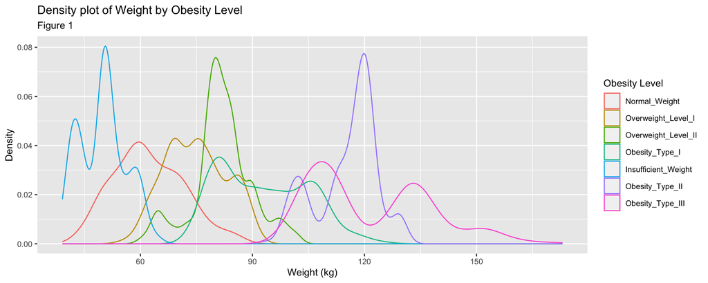

```r
weight_dist
```

Figure 1 shows the density of different weights with the various colours indicating different obesity level categories ranging from Insufficient Weight to Obesity Type III. Density is on the y-axis and weight (in kg) is shown on the x-axis. From the plot above, we can see that lower obesity level classes have higher density on smaller weight (left-side of the x-axis), while higher obesity level classes have higher density on larger weight (right-side of the x-axis). For example, Obesity Type II (the purple line) has the highest density of about 0.07 around 120 kg while normal weight has a peak of density (~0.04) at 60 kg. This indicates that Weight has a strong correlation with Obesity Level where higher obesity level classes are associated with larger weight.

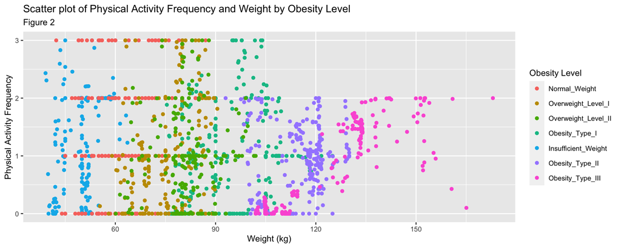

```r
weight_faf_plot
```

In figure 2, we can see that Physical Activity Frequency has a strong contribution to the classifier only on the higher end of Weight (around 105 kg and above).

### Finding the best K to use

To find the best K for our classifier, we are going to follow these few steps: 1. We will generate five different train/validation splits of our overall training data 2. Create the appropriate model specification and standardized recipe for tuning the classifier 3. We choose to test 20 values of K (1 - 20) 4. Create our workflow to find the accuracy for each value in a range of K values

```r
set.seed(255)

min_vfold <- vfold_cv(obesity_train, v = 5, strata = NObeyesdad)

min_spec <- nearest_neighbor(weight_fun = "rectangular", neighbors = tune()) %>%
            set_engine("kknn") %>%
            set_mode("classification")

obesity_recipe <- recipe(NObeyesdad ~ Weight + FAF + CH2O + TUE, data = obesity_train) %>%
                step_scale(all_predictors()) %>%
                step_center(all_predictors())

k_vals <- tibble(neighbors = seq(from = 1, to = 20, by = 1))

k_data <- workflow() %>%
        add_recipe(obesity_recipe) %>%
        add_model(min_spec) %>%
        tune_grid(resamples = min_vfold, grid = k_vals) %>%
        collect_metrics() %>%
        filter(.metric == "accuracy")

print("Table 4")
```

```
## [1] "Table 4"
```

```r
kable(head(k_data))
```

| neighbors | .metric | .estimator | mean | n | std_err | .config |
| --- | --- | --- | --- | --- | --- | --- |
| 1 | accuracy | multiclass | 0.7388297 | 5 | 0.0099930 | Preprocessor1_Model01 |
| 2 | accuracy | multiclass | 0.7381968 | 5 | 0.0090567 | Preprocessor1_Model02 |
| 3 | accuracy | multiclass | 0.7165827 | 5 | 0.0077056 | Preprocessor1_Model03 |
| 4 | accuracy | multiclass | 0.7122002 | 5 | 0.0094003 | Preprocessor1_Model04 |
| 5 | accuracy | multiclass | 0.6943513 | 5 | 0.0135944 | Preprocessor1_Model05 |
| 6 | accuracy | multiclass | 0.6880339 | 5 | 0.0139453 | Preprocessor1_Model06 |

In table 4, we can see the mean accuracy of our first six values of neighbors (K). To ease things, we are going to plot the accuracy versus K to decide which number of neighbors is the best.

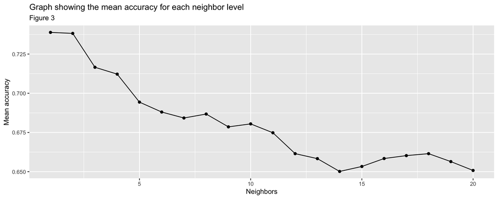

```r
k_plot <- ggplot(k_data, aes(x = neighbors, y = mean)) +
            geom_line() +
            geom_point() +
            labs(x = "Neighbors",
                 y = "Mean accuracy",
                 title = "Graph showing the mean accuracy for each neighbor level",
                 subtitle = "Figure 3") +
            theme(text = element_text(size = 10))

k_plot
```

```r
k_min <- k_data %>%
            arrange(desc(mean)) %>%
            slice(1) %>%
            pull(neighbors)

k_min
```

```
## [1] 1
```

### Using our K to create the model

Now that we have the best value for K, we use this K to build our classifier: 1. We create a new model specification using our new K 2. Build our classifier by combining our new model spec and recipe into a workflow and fit it with the training data

```r
set.seed(255)

obesity_spec <- nearest_neighbor(weight_fun = "rectangular", neighbors = k_min) %>%
                set_engine("kknn") %>%
                set_mode("classification")


obesity_fit <- workflow() %>%
        add_recipe(obesity_recipe) %>%
        add_model(obesity_spec) %>%
        fit(obesity_train)
```

## Testing the model

Test our K-nearest neighbors classifier object’s accuracy by using it to predict our testing data

```r
set.seed(255)
predictions <- predict(obesity_fit, obesity_test) %>%
                bind_cols(obesity_test)

print("Table 5")
```

```
## [1] "Table 5"
```

```r
kable(head(predictions))
```

| .pred_class | Weight | FAF | CH2O | TUE | NObeyesdad |
| --- | --- | --- | --- | --- | --- |
| Normal_Weight | 64 | 1 | 1 | 1 | Normal_Weight |
| Obesity_Type_I | 105 | 2 | 2 | 2 | Obesity_Type_I |
| Normal_Weight | 80 | 3 | 1 | 2 | Overweight_Level_II |
| Overweight_Level_I | 87 | 0 | 1 | 0 | Obesity_Type_I |
| Overweight_Level_I | 65 | 1 | 1 | 2 | Normal_Weight |
| Insufficient_Weight | 62 | 2 | 1 | 0 | Normal_Weight |

Table 5 shows the first six predictions we made on our testing data.

```r
obesity_metrics <- predictions %>%
                metrics(truth = NObeyesdad, estimate = .pred_class)

obesity_conf_mat <- predictions %>%
                conf_mat(truth = NObeyesdad, estimate = .pred_class)


print("Table 6")
```

```
## [1] "Table 6"
```

```r
kable(obesity_metrics)
```

| .metric | .estimator | .estimate |
| --- | --- | --- |
| accuracy | multiclass | 0.7396226 |
| kap | multiclass | 0.6958570 |

```r
print("Table 7")
```

```
## [1] "Table 7"
```

```r
obesity_conf_mat
```

```
##                      Truth
## Prediction            Normal_Weight Overweight_Level_I Overweight_Level_II
##   Normal_Weight                  54                 13                   9
##   Overweight_Level_I              8                 41                  10
##   Overweight_Level_II             4                 10                  30
##   Obesity_Type_I                  1                  5                  22
##   Insufficient_Weight             5                  3                   1
##   Obesity_Type_II                 0                  1                   1
##   Obesity_Type_III                0                  0                   0
##                      Truth
## Prediction            Obesity_Type_I Insufficient_Weight Obesity_Type_II
##   Normal_Weight                    1                   6               0
##   Overweight_Level_I              14                   1               0
##   Overweight_Level_II             10                   0               1
##   Obesity_Type_I                  60                   0               1
##   Insufficient_Weight              0                  61               0
##   Obesity_Type_II                  1                   0              69
##   Obesity_Type_III                 2                   0               4
##                      Truth
## Prediction            Obesity_Type_III
##   Normal_Weight                      0
##   Overweight_Level_I                 0
##   Overweight_Level_II                0
##   Obesity_Type_I                     1
##   Insufficient_Weight                0
##   Obesity_Type_II                    3
##   Obesity_Type_III                  77
```

### Prediction

```r
set.seed(255)
new_obs <- tibble(Weight = runif(1,60,100), FAF = runif(1,0,3), CH2O = runif(1,0,2), TUE = runif(1,0,3), NObeyesdad = "Unknown")

obesity_new <- rbind(obesity, new_obs)

new_pred <- predict(obesity_fit, new_obs) %>%
                    bind_cols(new_obs) %>%
                    rename(Prediction = .pred_class) %>%
                    select(-"NObeyesdad") %>%
                    relocate(Prediction, .after = TUE)

print("Table 8")
```

```
## [1] "Table 8"
```

```r
kable(new_pred)
```

| Weight | FAF | CH2O | TUE | Prediction |
| --- | --- | --- | --- | --- |
| 80.9716 | 1.708775 | 1.08269 | 1.419376 | Overweight_Level_II |

For the unknown new observation, the classifier predicted the obesity level class of the individual to be Overweight Level II.

## Visualization of the analysis

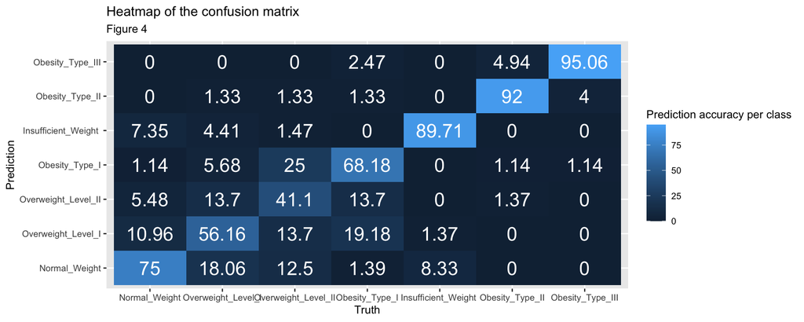

```r
options(repr.plot.width = 20, repr.plot.length = 20)
names <- c("Normal_Weight", "Overweight_Level_I", "Overweight_Level_II", "Obesity_Type_I", "Insufficient_Weight ","Obesity_Type_II", "Obesity_Type_III")

matrix <- matrix(unlist(obesity_conf_mat), ncol = 7, nrow = 7)

matrix_df <- round((matrix/colSums(matrix))*100,2) %>%
                        as.data.frame()

colnames(matrix_df)  <- names

matrix_df_2 <-  matrix_df %>%
                mutate(Prediction = names) %>%
                relocate(Prediction, .before = Normal_Weight) %>%
                melt()
matrix_df_2$Prediction <- factor(matrix_df_2$Prediction,levels=names)
matrix_df_2$variable <- factor(matrix_df_2$variable, levels=names)

matrix_heatmap <- ggplot(matrix_df_2, aes(x = variable, y = Prediction, fill = value)) +
                    geom_tile() +
                    geom_text(aes(label = value), color = "white", size = 6) +
                    labs(x = "Truth",
                         y = "Prediction",
                         fill = "Prediction accuracy per class",
                         title = "Heatmap of the confusion matrix",
                         subtitle = "Figure 4") +
                    theme(text = element_text(size = 10))

matrix_heatmap
```

# Discussion

### Impacts:

Classifying the new observation into an obese level category can help the individual know their level of obesity and its relationship with their lifestyle. By knowing which habits are negatively affecting their health, individuals may then make various changes in their current lifestyle in order to live a healthier life. In this case, the new observation has been classified as an obesity level category of Overweight Level II. This classification can impact the individual’s lifestyle decisions such as deciding to eat healthier or exercise more frequently to reduce their obesity level category and try to fall in the normal category. These classifications can help these individuals live longer and healthier by raising awareness of their weight-health.

### Future Questions:

In the future, we could look into possible diseases in relation to different stages of obesity (eg. What is the relation between obesity and heart diseases?) Another interesting future question would be to look into categorizing the new observations with other predictors that are not given from this dataset that are also relevant to obesity/weight levels (eg. family history/genetic factors/wealth). Related to this, it would be interesting to perform this study with all given dataset predictors rather than just the four used for the purpose of this study.

# References:

Nguyen, D. M., & El-Serag, H. B. (03/2010). The epidemiology of obesity WB Saunders Company. doi:10.1016/j.gtc.2009.12.014

Trivedi, S., Burton, A., & Oden, J. (02/2014). Management of pediatric obesity: A lifestyle modification approach [s.n. doi:10.1007/s12098-013-1138-0

### Dataset:

https://archive.ics.uci.edu/ml/datasets/Estimation+of+obesity+levels+based+on+eating+habits+and+physical+condition+#